# Final Exam Review

Neha Maddali

2023-12-04

## 1. Bias Variance Tradeoff

### Definition of bias and variance in mathematical terms

- Bias($\hat{f}(x_{0})$) = E($f(x_{0}) - \hat{f}(x_0)$)
- Var($\hat{f}(x_{0})$) = E($\hat{f}(x_{0})$ - E($\hat{f}(x_{0})$)))$^2$

### Definition of bias and variance in conceptual terms (plain language)

- Bias refers to the error that is introduced by approximating our real-life phenomenon
- Variance refers to the amount by which our model would change if we had estimated it using a different training set

### How bias and variance behaves in supervised learning methods

- In supervised learning, there’s a tradeoff between bias and variance. As you increase the complexity of the model, bias decreases but variance increases, and vice versa. The challenge is finding the right balance to minimize overall prediction error
- more flexible methods –> higher varaince and lower bias
- the expected test MSE is never < irreducible error
- expected test MSE = var + bias$^{2}$ + irreducible error
- E($y_0 - \hat{f}(x_0)$)$^2$ = Var($\hat{f}(x_{0})$) + [Bias($\hat{f}(x_{0})$)]$^2$ + Var($\epsilon$)

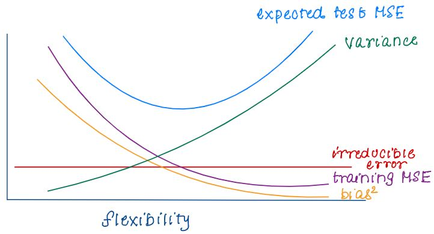

### Calculate bias (square) and variance for simulated data

- Midterm 1, Question 2

  ```r
  set.seed(1) # generate 100 observations from the true regression model
  n = 100
  x = runif(n, min = 0, max = 2)
  error = rnorm(n,0,1)
  y = 4 + x + x^2 + x^3 + error
  train_set = data.frame(x,y)

  M1 = lm(y~x,data=train_set)
  M2 = lm(y~poly(x,degree=2),data=train_set)
  M3 = lm(y~poly(x,degree=3),data=train_set)
  M4 = lm(y~poly(x,degree=5),data=train_set)
  M5 = lm(y~poly(x,degree=11),data=train_set)

  ######### Problem 2.1 ###########
  # simulate 1000 training sets
  # for each of these 1000 training sets, train M1-M5
  # store the predicted values fhat(x_0) when x = 0.9
  # report the first 5 predicted values for each model
  set.seed(1)
  pred1 = pred2 = pred3 = pred4 = pred5 = rep(NA,1000)

  for (i in 1:1000){
    error=rnorm(n,0,1)
    y=4+x+x^2+x^3 + error
    train_set = data.frame(x,y)

    M1 = lm(y~x,data=train_set)
    M2 = lm(y~poly(x,degree=2),data=train_set)
    M3 = lm(y~poly(x,degree=3),data=train_set)
    M4 = lm(y~poly(x,degree=5),data=train_set)
    M5 = lm(y~poly(x,degree=11),data=train_set)

    pred1[i] = predict(M1,newdata=data.frame(x=.9))
    pred2[i] = predict(M2,newdata=data.frame(x=.9))
    pred3[i] = predict(M3,newdata=data.frame(x=.9))
    pred4[i] = predict(M4,newdata=data.frame(x=.9))
    pred5[i] = predict(M5,newdata=data.frame(x=.9))
  }
  pred1[1:5]
  ```

  ```
  ## [1] 7.559240 7.438056 7.504140 7.539358 7.415642
  ```

  ```r
  pred2[1:5]
  ```

  ```
  ## [1] 6.293302 6.308767 6.479241 6.359311 6.411642
  ```

  ```r
  pred3[1:5]
  ```

  ```
  ## [1] 6.323219 6.390942 6.512884 6.407827 6.463554
  ```

  ```r
  pred4[1:5]
  ```

  ```
  ## [1] 6.269641 6.668993 6.553530 6.360533 6.315840
  ```

  ```r
  pred5[1:5]
  ```

  ```
  ## [1] 6.433107 6.626336 6.664579 6.454152 6.313504
  ```

  ```r
  ######### Problem 2.2 ###########
  # use results from above to get Bias(fhat(x_0))^2 for each     model when x_0 = 0.9
  x0=.9
  true_y = 4+(x0)+(x0)^2+(x0)^3
  bias1 = (mean(pred1)-true_y)^2
  bias2 = (mean(pred2)-true_y)^2
  bias3 = (mean(pred3)-true_y)^2
  bias4 = (mean(pred4)-true_y)^2
  bias5 = (mean(pred5)-true_y)^2
  biases = c(bias1, bias2, bias3, bias4, bias5)
  #plot(biases)

  ######### Problem 2.3 ###########
  # use results from above to get Var(fhat(x_0)) for each model when x_0 = 0.9
  x0=.9
  true_y = 4+(x0)+(x0)^2+(x0)^3
  var1 = mean((pred1-mean(pred1))^2)
  var2 = mean((pred2-mean(pred2))^2)
  var3 = mean((pred3-mean(pred3))^2)
  var4 = mean((pred4-mean(pred4))^2)
  var5 = mean((pred5-mean(pred5))^2)
  vars = c(var1, var2, var3, var4, var5)
  #plot(vars)

  ######### Problem 2.5 ###########
  # get all five models expected test MSE
  (bias1) + var1 + 1
  ```

  ```
  ## [1] 2.071535
  ```

  ```r
  (bias2) + var2 + 1
  ```

  ```
  ## [1] 1.022488
  ```

  ```r
  (bias3) + var3 + 1
  ```

  ```
  ## [1] 1.02131
  ```

  ```r
  (bias4) + var4 + 1
  ```

  ```
  ## [1] 1.031817
  ```

  ```r
  (bias5) + var5 + 1
  ```

  ```
  ## [1] 1.060193
  ```

  ```r
  ######### Problem 2.7 ###########
  # estimate of the irreducible error for the models
  (1/(100-(1+1)))*sum((true_y-pred1)^2)
  ```

  ```
  ## [1] 10.93403
  ```

  ```r
  (1/(100-(1+1)))*sum((true_y-pred2)^2)
  ```

  ```
  ## [1] 0.2294692
  ```

  ```r
  (1/(100-(1+1)))*sum((true_y-pred3)^2)
  ```

  ```
  ## [1] 0.2174478
  ```

  ```r
  (1/(100-(1+1)))*sum((true_y-pred4)^2)
  ```

  ```
  ## [1] 0.3246597
  ```

  ```r
  (1/(100-(1+1)))*sum((true_y-pred5)^2)
  ```

  ```
  ## [1] 0.6142194
  ```

## 2. Multiple Linear Regression

### Setup the model. Estimate parameters in this model (mathematically and conceptually)

- to find the estimate for $\hat{\beta}$
  - find the $\hat{\beta}$’s that minimize the RSS (residual sum of squares)
- To estimate the parameters (B coefficients), the least squares method is used.
  - The goal is to minimize the sum of squared differences between the observed and predicted values.
  - $\sum_{i=1}^{n} (y_i - (\hat{\beta_0} + \hat{\beta_1}X_{i1} + ...))^2$
  - interpretation of least squares coefficient
    - $\hat{Y} = \hat{\beta_0} + \hat{\beta_1}X_1 + ...$
      - $\hat{\beta_j}$ can be interpreted as the average change in Y associated with a 1 unit change in $X_j$, holding all other predictors constant
  - the estimates are good in the least square estimates $\hat{\beta}$ are unbiased
    - idea: obtain huge number of beta hats from many training data sets, then the average of them would exactly = B
    - refer to HW2 Q1

  ```r
  X1 = seq(0,10,length.out =100) #generates 100 equally spaced values from 0 to 10.
  X2 = runif(100) #generates 100 uniform values.
  n = 100
  beta_0 = 2
  beta_1 = 3
  beta_2 = 5

  error = rnorm(n,0,1)
  Y = beta_0 + beta_1*X1 + beta_2*log(X2) + error

  #simulation to show that Bhat0, Bhat1, Bhat2 is an unbiased estimator of B0, B1, B2
  B = 5000
  beta0hat = beta1hat = beta2hat = rep(NA,B)
  for(i in 1:B){
    error = rnorm(n,0,1)
    Y = beta_0 + beta_1*X1 + beta_2*log(X2) + error
    fit = lm(Y~X1 + log(X2))
    beta0hat[i] = fit$coefficients[[1]]
    beta1hat[i] = fit$coefficients[[2]]
    beta2hat[i] = fit$coefficients[[3]]

  }
  mean(beta0hat)
  ```

  ```
  ## [1] 2.000731
  ```

  ```r
  mean(beta1hat)
  ```

  ```
  ## [1] 2.999924
  ```

  ```r
  mean(beta2hat)
  ```

  ```
  ## [1] 5.000523
  ```

### When the method breaks down

- Multicollinearity: when independent variables are highly correlated, it can be challenging to separate their individual effects, leading to unstable coefficient estimates
- Outliers: the presence of outliers in the data can disproporitonately influence the rergession model, leading to biased parameter estimates
- Non-linearity: if the relationship between the dependent and independent variables is not linear, MLR may not be appropriate.

### When the method does well

- Linearity: when the relationship between the dependent and independent variables is approximately linear, MLR is a suitable modeling technique
- Independence of errors: the errors (residuals) should be independent of each other. No systematic pattern in the residuals should be present
- Homoescedasticity: the variabce of the residuals should be constant across all levels of the independent variables
  - Residuals vs. Fitted Values Plot
- Normality of errors: the errors should be normally distributed
  - Quantile-Quantile Plot

## 3. Inference for MLR and Multiple Testing Problems

### Assumptions needed

- relationship between Y and X is approximately linear
- E($\epsilon$) = 0
- Var($\epsilon$) = $\sigma^2$
- residual_variance = summary(model)$sigma^2
- $\epsilon$’s are uncorrelated
- Hypothesis Test Examples
  - Midterm 1 Q1
    - H0: B2 = 0 versus H1: B2 ≠ 0  
      Test statistic = 6.377  
      Null distribution: t distribution with 4997 degrees of freedom  
      P-value: 2.49e-10  
      Conclusion: We have evidence at the α = 0.01 significance level that the regression coefficient associated with X2 is significantly different from 0
  - HW3 Problem 1, Part e

### Confidence intervals vs. prediction intervals

- sources of uncertainty
  - reducible error
  - model bias
  - irreducible error
- use confidence interval to quantify the uncertainty surrounding the “average patient score” given a set of predictors
  - reducible error
- use prediction interval to quantify the uncertainty surrounding the “satisfaction score for a particular patient” given a set of predictors
- Example HW3 Problem 1

  ```r
    library(ISLR2)
    model <- lm(Sales ~ CompPrice + Income + Advertising + Population + Price + Age + Education + Urban + US, data = Carseats)

    # Create a data frame for prediction
    Xh <- data.frame(
      CompPrice = mean(Carseats$CompPrice),
      Income = median(Carseats$Income),
      Advertising = 15,
      Population = 500,
      Price = 50,
      Age = 30,
      Education = 10,
      Urban = factor("Yes", levels = levels(Carseats$Urban)),
      US = factor("Yes", levels = levels(Carseats$US))
    )

    #predict(model,newdata=Xh)
    predict(model,newdata=Xh,interval='confidence',level=0.95)
  ```

  ```
  ##        fit      lwr      upr
  ## 1 15.80707 14.91953 16.69461
  ```

  ```r
    predict(model,newdata=Xh,interval='prediction',level=0.95)
  ```

  ```
  ##        fit      lwr      upr
  ## 1 15.80707 11.90593 19.70821
  ```

## 4. Model Selection

### Model Selection techniques available (mathematically and conceptually)

- Model Selection Strategy
  - p is small (p < 30)
    - exhaustive search (“best” subset selection)
  - p is large (p $\geq$ 30)
    - greedy algorithm (forward/backward selection)
- Best Subset Selection
  1. for all k = 1, … p
     1. fit all $\binom{p}{k}$ models that contain exactly k predictors
     2. pick among these $\binom{p}{k}$ models the best one of size k. call this model $M_k
        - best is defined as the model with smallest RSS
  2. set of candidate models: $M_1, M_2, ...M_p$
     - select best model among these candidate models
  - criteria
    - (false) RSS will decrease or stay the same as we add predictors
    - AIC (want smallest) = $nlog(RSS/n)+2p$
      - used more frequently
      - assumes true model not in candidate pool
      - tries to mimic the true model
    - BIC (want smallest) = $nlog(RSS/n) + plog(n)$
      - has a heavier penalty term
      - will usually pick a simpler/more parimonous model
      - is consistent: if the true model is among candidate pool it will eventually lead to the true model (if n is large enough)
    - adjusted $R^2$ (want highest) = $1 - \frac{RSS/(n-(p+1))}{\sum_{i=1}^{n} (y_i - \bar{y})^2/n-1}$
    - Mallow’s Cp = $(RSS/\sigma^2) - n + 2p$
    - if decrease in RSS isn’t enough to offset penalty (price to be in model) it leads to increase in our criteria which we don’t want
- Stepwise Selection (large p)
  - Forward Stepwise Selection
    1. let $M_0$ denote the null model, which contains no predictors
    2. For k=0, … p-1
       1. consider all p-k models that augment the predictors in $M_k$ with one additional predictor
       2. choose the best among these p-k models and call it $M_{k+1}$. Here, best is defined as the model with the smallest RSS
    3. select a best model $M_1, ...M_p$ using cross validation error, AIC, BIC, Mallow’s Cp or adjusted $R^2$
    - simpler model? FORWARD
    - high dimensional data? FORWARD
  - Backward Stepwise Selection
    - same algorithm as forward, just direction moves backwards
    - initial model: full model
    - iteratively remove each predictor one at a time
    - goal is prediction and more complex model acceptable? BACKWARD
  - Hybrid Approach
    - stepwise selection is a hybrid of forward/backward
    - at each step you are not restricted to one direction (you can add or remove predictors)
    - attempts to mimic subset selection while retaining computational advantage ### Strengths and Limitations of each approach
- Best Subset Selection
  - Strengths
    - considers all possible combinations of predictors, ensuring the selected model is the one that minimizes specified criteria.
    - easier to interpret relationships between predictors and response
    - provides a way to directly compare models with differen numbers of predictors
  - Limitations
    - as the number of predictors increase, the number of possible subsets grows exponentially, making it computationally expensive
    - prone to overfitting, especially when the number of predictors is close to the number of observations
    - may not be practical for large datasets due to computational demands
- Stepwise Selection
  - Strengths
    - computationally efficient
    - more practical for large datasets since it starts with a minimal model and adds predictors one at a time, reducing risk of overfitting
  - Limitations
    - might not always find best model. it may overlook combinations of predictors that collectively yield a better model
    - assumes linearity between predictors and response

### Implementation details. For example, is AIC computed on the full dataset or training set only?

- Best Subset Selection
  - Refer to Simulation Study in HW4 Question 2 for additional information
  - HW4 Question 1
    - We will use this data set to practice 3 common subset selection approaches.
    - Approach 1: Perform best subset selection on the entire data set with lpsa as the response. For each model size, you will obtain a ’best’ model (size here is just the number of predictors in the model): M1 is the best model with 1 predictor (size 1), M2 is the best model with 2 predictors (size 2), and so on. Create a table of the AIC, BIC, adjusted R2 and Mallow’s Cp for each model size. Report the model with the smallest AIC, smallest BIC, largest adjusted R2 and smallest Mallow’s Cp. Do they lead to different results? Using your own judgement, choose a final model.
    - Approach 2: The dataset has already been split into a training and test set. For each model size, you will obtain a ‘best’ model. Fit each of those models on the training set. Then evaluate the model performance on the test set by computing their test MSE. Choose a final model based on prediction accuracy. Fit that model to the full dataset and report your final model here
    - Approach 3: This approach is used to select the optimal size, not which predictors will end up in our model. Split the dataset into k folds (you decide what k should be). We will perform best subset selection within each of the k training sets. Here are more detailed instructions:
      1. For each fold k = 1, . . . , K:
         1. Perform best subset selection using all the data except for those in fold k (training set). For each model size, you will obtain a ‘best’ model.
         2. For each ‘best’ model, evaluate the test MSE on the data in fold k (test set).
         3. Store the test MSE for each model.  
            Once you have completed this for all k folds, take the average of your test MSEs for each model size. In other words, for all k models of size 1, you will compute their kfold cross-validated error. For all the k models of size 2, you will compute their k-fold cross-validated errors, and so on. Report your 8 CV errors here.
      2. Choose the model size that gives you the smallest CV error. Now perform best subset selection on the full data set again in order to obtain this final model. Report that model here. (For example, suppose cross-validation selected a 5-predictor model. I would perform best subset selection on the full data set again in order to obtain the 5-predictor model.)

  ```r
  # APPROACH 1
  prostate = read.table("/Users/neham/Desktop/DS303/HW/prostate.data",header=TRUE)
  library(leaps)

  regfit = regsubsets(lpsa~.,data=prostate,nbest=1,nvmax=9)
  regfit.sum = summary(regfit)
  n = dim(prostate)[1]
  p = rowSums(regfit.sum$which)
  adjr2 = regfit.sum$adjr2
  cp = regfit.sum$cp
  rss = regfit.sum$rss
  AIC = n*log(rss/n) + 2*(p)
  BIC = n*log(rss/n) + (p)*log(n)

  cbind(p,adjr2,cp,AIC,BIC)
  ```

  ```
  ##    p     adjr2        cp       AIC       BIC
  ## 1  2 0.5345839 26.038827 -44.36603 -39.21661
  ## 2  3 0.5868977 13.546389 -54.95846 -47.23433
  ## 3  4 0.6242063  5.092716 -63.17744 -52.87859
  ## 4  5 0.6280585  5.126817 -63.22555 -50.35199
  ## 5  6 0.6335279  4.785451 -63.72263 -48.27437
  ## 6  7 0.6349654  5.450474 -63.17571 -45.15273
  ## 7  8 0.6365002  6.099923 -62.66823 -42.07054
  ## 8  9 0.6327886  8.000636 -60.77886 -37.60646
  ## 9 10 0.6285705 10.000000 -58.77957 -33.03246
  ```

  ```r
  which.min(BIC)
  ```

  ```
  ## 3
  ## 3
  ```

  ```r
  which.min(AIC)
  ```

  ```
  ## 5
  ## 5
  ```

  ```r
  which.min(cp)
  ```

  ```
  ## [1] 5
  ```

  ```r
  which.max(adjr2)
  ```

  ```
  ## [1] 7
  ```

  ```r
  coef(regfit,5)
  ```

  ```
  ## (Intercept)      lcavol     lweight         age        lbph         svi
  ##  0.49472926  0.54399786  0.58821270 -0.01644485  0.10122333  0.71490398
  ```

  ```r
  # APPROACH 2
  train = subset(prostate,train==TRUE)[,1:9]
  test = subset(prostate,train==FALSE)[,1:9]
  best.train = regsubsets(lpsa~.,data=train,nbest=1,nvmax=8)

  val.errors = rep(NA,8)
  for(i in 1:8){
    test.mat = model.matrix(lpsa~.,data=test)
    coef.m = coef(best.train,id=i)
    pred = test.mat[,names(coef.m)]%*%coef.m
    val.errors[i] = mean((test$lpsa-pred)^2)
  }
  val.errors
  ```

  ```
  ## [1] 0.4797387 0.4924823 0.4005308 0.4563321 0.4859242 0.5485933 0.5165135
  ## [8] 0.5212740
  ```

  ```r
  which.min(val.errors)
  ```

  ```
  ## [1] 3
  ```

  ```r
  coef(regfit,3)
  ```

  ```
  ## (Intercept)      lcavol     lweight         svi
  ##  -0.7771566   0.5258519   0.6617699   0.6656666
  ```

  ```r
  # APPROACH 3 part i
  k = 10
  folds = sample(1:k,nrow(prostate),replace=TRUE)
  val.errors = matrix(NA,k,8)

  for(j in 1:k){
    test = prostate[folds==j,]
    train = prostate[folds!=j,]
    best.fit = regsubsets(lpsa~.,data=train,nbest=1,nvmax=8)

    for(i in 1:8){
      test.mat = model.matrix(lpsa~.,data=test)
      coef.m = coef(best.fit,id=i)
      pred = test.mat[,names(coef.m)]%*%coef.m
      val.errors[j,i] = mean((test$lpsa-pred)^2)
    }
  }
  cv.errors = apply(val.errors,2,mean)
  which.min(cv.errors)
  ```

  ```
  ## [1] 7
  ```

  ```r
  # APPROACH 3 part ii
      regfit = regsubsets(lpsa~.,data=prostate,nbest=1,nvmax=9)
  regfit.sum = summary(regfit)

  n = dim(prostate)[1]
  p = rowSums(regfit.sum$which)
  adjr2 = regfit.sum$adjr2
  cp = regfit.sum$cp
  rss = regfit.sum$rss
  AIC = n*log(rss/n) + 2*(p)
  BIC = n*log(rss/n) + (p)*log(n)

  cbind(p,rss,adjr2,cp,AIC,BIC)
  ```

  ```
  ##    p      rss     adjr2        cp       AIC       BIC
  ## 1  2 58.91478 0.5345839 26.038827 -44.36603 -39.21661
  ## 2  3 51.74218 0.5868977 13.546389 -54.95846 -47.23433
  ## 3  4 46.56844 0.6242063  5.092716 -63.17744 -52.87859
  ## 4  5 45.59547 0.6280585  5.126817 -63.22555 -50.35199
  ## 5  6 44.43668 0.6335279  4.785451 -63.72263 -48.27437
  ## 6  7 43.77597 0.6349654  5.450474 -63.17571 -45.15273
  ## 7  8 43.10756 0.6365002  6.099923 -62.66823 -42.07054
  ## 8  9 43.05842 0.6327886  8.000636 -60.77886 -37.60646
  ## 9 10 43.05810 0.6285705 10.000000 -58.77957 -33.03246
  ```

  ```r
  which.min(BIC)
  ```

  ```
  ## 3
  ## 3
  ```

  ```r
  which.min(AIC)
  ```

  ```
  ## 5
  ## 5
  ```

  ```r
  which.min(cp)
  ```

  ```
  ## [1] 5
  ```

  ```r
  which.max(adjr2)
  ```

  ```
  ## [1] 7
  ```

  ```r
  coef(regfit,7)
  ```

  ```
  ##  (Intercept)       lcavol      lweight          age         lbph          svi
  ##  0.494154748  0.569546032  0.614419818 -0.020913467  0.097352534  0.752397341
  ##          lcp        pgg45
  ## -0.104959408  0.005324465
  ```

- Forward/Backward Stepwise Selection
  - HW5 Problem 2
    - Suppose we perform subset, forward stepwise, and backward stepwise selection on a single data set. For each approach, we can obtain p models containing k = 1, 2, . . . , p predictors. For a given k, best subset will give us a best model with k predictors. Call this $M_{k,subset}$. Forward stepwise selection will give us a best model with k predictors. Call this $M_k,forward$. Backward stepwise selection will give us a best model with k predictors. Call this $M_{k,backward}$. For a given k, which of these three models has the smallest training MSE?
      - Training MSE is just a function of RSS. By definition, subset selection will recover the model with the smallest RSS and therefore the smallest training MSE. Since forward and backward selection is greedy, there is no guarantee that they will obtain the model with the smallest RSS. Therefore, for a given k, $M_{k, subset}$ will have the smallest training MSE
    - Same setup as part a. For a given k, which of these three models has the smallest test MSE?
      - Since the test set is data we haven’t seen before, it’s not possible for any of the three methods to yield the best test MSE due to the randomness in the test set.
    - Use the College data set ISLR2 library to predict the number of applications (Apps) each university received. Randomly split the data set so that 90% of the data belongto the training set and the remaining 10% belong to the test set. Implement forward and backward selection on the training set only. Do they lead you to the same model? For each approach, report the best model based on AIC. From these 2 models, pick a final model based on their performance on the test set. Report both model’s test MSE and summarize your final model.
      - ended up with the same model for both backward and forward selection.

  ```r
  library(ISLR2)
  library(leaps)
  n = dim(College)[1]
  train = sample(1:n, 0.9*n, replace = FALSE)
  train_College = College[train,]
  test_College = College[-train,]

  regfit.fwd = regsubsets(Apps~., data = train_College, nvmax=17, method="forward")
  regfit.bwd = regsubsets(Apps~., data = train_College, nvmax=17, method="backward")

  regfit.fwd.sum = summary(regfit.fwd)
  p =  rowSums(regfit.fwd.sum$which) #number of predictors + intercept in the model
  rss = regfit.fwd.sum$rss
  AIC_fwd = n*log(rss/n) + 2*(p)
  which.min(AIC_fwd)
  ```

  ```
  ## 13
  ## 13
  ```

  ```r
  coef(regfit.fwd, 11)
  ```

  ```
  ##   (Intercept)    PrivateYes        Accept        Enroll     Top10perc
  ##  -60.27262946 -516.37360881    1.62243891   -1.14726541   47.81646564
  ##     Top25perc   F.Undergrad      Outstate    Room.Board           PhD
  ##  -14.34689975    0.09470908   -0.10007092    0.13865461  -11.38384321
  ##        Expend     Grad.Rate
  ##    0.08702247    9.25093016
  ```

  ```r
  regfit.bwd.sum = summary(regfit.bwd)
  p = rowSums(regfit.bwd.sum$which)
  rss = regfit.bwd.sum$rss
  AIC_bwd = n*log(rss/n) + 2*(p)
  which.min(AIC_bwd)
  ```

  ```
  ## 13
  ## 13
  ```

  ```r
  coef(regfit.bwd, 11)
  ```

  ```
  ##   (Intercept)    PrivateYes        Accept        Enroll     Top10perc
  ##  -60.27262946 -516.37360881    1.62243891   -1.14726541   47.81646564
  ##     Top25perc   F.Undergrad      Outstate    Room.Board           PhD
  ##  -14.34689975    0.09470908   -0.10007092    0.13865461  -11.38384321
  ##        Expend     Grad.Rate
  ##    0.08702247    9.25093016
  ```

  ```r
  test.mat = model.matrix(Apps~., data=test_College)
  coef.m = coef(regfit.fwd, id=11)
  pred = test.mat[,names(coef.m)]%*%coef.m
  test_MSE = mean((test_College$Apps-pred)^2)
  test_MSE
  ```

  ```
  ## [1] 1323115
  ```

### Protect against double-dipping.

- Midterm 2 Question 1 Problem 1
  - Your colleague performs ridge regression in R and estimates the optimal parameter lambda by 10 fold cross validation. You take a look at her code. Your colleague concludes that the optimal lambda = 0.5 and the test MSE of ridge regression with lambda = 0.5 is 485.1199. Do you agree with her approach? if so, explain why. If not, provide another way to estimate the test MSE.  
    library(glmnet)  
    X = as.matrix(data[,-1])  
    Y = as.vector(data[,1])  
    train = sample(1:nrow(X), nrow(X)/2)  
    test = (-train)  
    Y.test = Y[test]  
    grid = 10^seq(10,-2,length=100)  
    cv.out = cv.glmnet(X, Y, alpha=0, lambda=grid)  
    cv.out$lambda.min  
    ridge.train = glmnet(X[train,], Y[train], alpha=0, lambda=0.5)  
    ridge.pred = predict(ridge.train, s=0.5, newx=X[test,])  
    mean((ridge.pred-Y.test)^2)
  - The problem lies in the fact that the same data are used both for selecting the optimal lambda through cross validation (cv.glmnet) and for assessing the model’s performance (glmnet with the selected lambda). This is double dipping and can lead to an incorrect assessment of the model’s performance.
  - Instead, perform cross validation on a training set and then evaluate the model on a separate test set that was not used in the lambda selection process. This ensures that the model’s performance is assessed on unseen data

## 5. MLR other considerations

### Categorical predictors

- This data set contains a few categorical predictors. Change categorical predictors to factors

  ```r
  insurance = read.csv("/Users/neham/Desktop/DS303/Lecture/insurance.csv")
  insurance$gender = factor(insurance$gender)
  insurance$region = factor(insurance$region)
  insurance$smoker = factor(insurance$smoker)
  ```

- Fit a model with the response (Y) as health care charges and predictors
  - x_1 age, x2 = bmi, and x3 = gender.
  - Based on your output, write out the fitted model for males only (gendermale = 1) and
  - write out the fitted model for females only (gendermale = 0).

  ```r
  fit = lm(charges~age+bmi+gender,data=insurance)
  # males: Yhat = -5642.36 + 243.19*age + 327.54*bmi
  #females: Yhat = -6986.82 + 243.19*age + 327.54*bmi
  ```

- subset your data into two groups: data for males and data for females.
  - Fit a model with bmi and age for the male group only. Call this model fit_males.
  - Now do the same for the female group. Call this model fit_females.

  ```r
  males=insurance[insurance$gender=='male',]
  females=insurance[insurance$gender=='female',]

  fit_males = lm(charges~age+bmi,data=males)
  #males: Yhat = -8012.79 + 238.63*age + 409.87*bmi

  fit_females = lm(charges~age+bmi,data=females)
  #females: Yhat = -4515.22 + 246.92*age + 241.32*bmi

  # the following does the same thing, only with interaction terms
  fit = lm(charges~age+bmi+gender+age*gender+bmi*gender,data=insurance)
  #females: Yhat = -4515.29 + 246.9*age + 241.32*bmi
  #males: Yhat = -4515.219 + -3497 + (246.9 + -8.287)*age + (241.32+168.55)*bmi
  ```

### Interaction terms - When are they needed and how to decide if to include

- HW6 Problem 1
  - the simplest approach is to compare the test MSE of a model with/without interaction terms

  ```r
  index = sample(1:nrow(insurance), nrow(insurance)/2)
  train = insurance[index,]
  test = insurance[-index,]
  model1 = lm(charges~bmi+age+gender, data = train)
  model2 = lm(charges~bmi+age+gender+gender*age+gender*bmi, data = train)

  yhat1 = predict(model1, newdata = test)
  yhat2 = predict(model2, newdata = test)
  testMSE1 = mean((test$charges-yhat1)^2)
  testMSE2 = mean((test$charges-yhat2)^2)
  testMSE1
  ```

  ```
  ## [1] 127460992
  ```

  ```r
  testMSE2
  ```

  ```
  ## [1] 128065158
  ```

  ```r
  anova(model1, model2)
  ```

  ```
  ## Analysis of Variance Table
  ##
  ## Model 1: charges ~ bmi + age + gender
  ## Model 2: charges ~ bmi + age + gender + gender * age + gender * bmi
  ##   Res.Df        RSS Df Sum of Sq      F Pr(>F)
  ## 1    665 8.7503e+10
  ## 2    663 8.6976e+10  2 526854480 2.0081 0.1351
  ```

  ```r
  # the test MSE of model without interaction term was smaler than the model with the interaction term. The F-test was also non-significant at alpha=0.05. So the interaction term is not needed in the model
  ```

### Polynomial regression

- $Y_i = \beta_0 + \beta_1X_i + \beta_2X^2_i + ... + \beta_dX^d_i + \epsilon_i$
- unusual to use d > 3 or 4
- for large d, the polynomial curve can become overly flexible and start to model noise coefficients cam still be estimated using least squares as its considered a standard linear model
- all inference tools for linear models are still available in this setting

### Model diagnostics

- Look at HW3 Problem 3
- Assumptions for linear regression
  - relationship between Y and X is approximately linear
  - E($\epsilon$) = 0
  - Var($\epsilon$) = $\sigma^2$
    - residual_variance = summary(model)$sigma^2
  - $\epsilon$’s are uncorrelated
- non constant variance of error terms
  - assume error terms have constant variance (Var($\epsilon_i$) = $\sigma^2$)
  - to diagnose this, plot residuals vs fitted values from model. If constant variance assumption holds, plot exhibits random scatter.
  - possible solution: transform the response with log Y or $\sqrt{Y}$
- non linearity of the data
  - residual vs fitted values plot shows no pattern
  - possible solution: transform log X, $\sqrt{X}$, $X^2$

### Multicollinearity

  ```r
  set.seed(42)
  x1 = runif(100)
  x2 = 0.8*x1 + rnorm(100,0,0.1)
  b0 = 3
  b1 = 2
  b2 = 4
  error = rnorm(100,0,0.1)
  Y = b0 + b1*x1 + b2*x2 + error
  data = data.frame(Y=Y, X1=x1, X2=x2)
  cor(x1, x2)
  ```

  ```
  ## [1] 0.9404249
  ```

  ```r
  #split data into training and test. train model on training
  index = sample(1:nrow(data), nrow(data)/2)
  train = data[index,]
  test = data[-index,]
  model_cor = lm(Y~X1 + X2, data = train)
  model_cor_pred = predict(model_cor, newdata = test)
  mean((test$Y-model_cor_pred)^2) #test mse
  ```

  ```
  ## [1] 0.01043353
  ```

  ```r
  #repeat this process 2500 times
  MSE_test = rep(NA, 2500)
  for(i in 1:2500){
    epsilon = rnorm(100, mean=0, sd=2)
    y=b0+b1*x1+b2*x2 + epsilon
    data = data.frame(y, x1, x2)
    n=dim(data)[1]
    train_index = sample(1:n, n/2, replace=FALSE)
    train = data[train_index,]
    test = data[-train_index,]
    lm_train = lm(y~x1+x2, data = train)
    MSE_test[i] = mean((predict(newdata = test, object=lm_train)- test$y)^2)
  }

  mean_MSE1 = round(mean(MSE_test), 2)
  mean_MSE1
  ```

  ```
  ## [1] 4.28
  ```

  ```r
  #now generate predictors without multicollinearity
  set.seed(24)
  x1 = runif(100)
  x2 = rnorm(100, 0, 1)
  error = rnorm(100,0,2)
  Y = beta_0 + beta_1*x1 + beta_2*x2 + error
  cor(x1,x2)
  ```

  ```
  ## [1] 0.03316596
  ```

## 6. Resampling Methods: Cross-Validation and Bootstrap

### Cross Validation

- Hw4 Question 3
  1. Explain how k-fold cross-validation is implemented.
     - The dataset is divided into k roughly equal folds. A fold is chosen to be the test set and the reamining observations are the training set. This process is repeated so that each fold gets the chance to be the test set. The average of the k-test MSEs from this process is our k-fold cross validation error.
  2. What are the advantages and disadvantages of k-fold cross-validation relative to:
     1. The validation set approach?
        - Advantage of k-fold is we get to utilize more data for training/testing purposes
        - Disadvantage is that it’s not as easy to implement and can be more computationally intensive to implement
     2. LOOCV?
        - Advantage is that k-fold CV is less computationally intensive than LOOCV (the exception is for linear models)
        - Disadvantage is that k-fold utilizes less data and it still has randomness
  3. perform cross-validation on a simulated data set. Generate a simulated data set such that $Y=X-2X^2 + \epsilon$ with $\epsilon$ ~ $N(0,1^2)$
  4. Fit a linear model to the data set you simulated (y ∼ x) and check whether or not the linearity assumption holds. Present the corresponding diagnostic plot and interpret what you observe.
     - We know that the linearity assumption is violated (because of the way the data is generated). The diagnostic plot clearly illustrates this: there is a discernible pattern to the residuals and the red line has clear curvature
  5. Set a random seed, and then compute the LOOCV errors that result from fitting the following 4 models using lm and poly:  
     M1 : a linear model with X  
     M2 : a polynomial regression model with degree 2  
     M3 : a polynomial regression model with degree 3  
     M4 : a polynomial regression model with degree 4
  6. Repeat the above step using another random seed, and report your results. Are your results the same as what you got in part d. Why?
     - yes, the results should be exactly the same. there is no randomness in LOOCV because each observations gets a change to be left out as the test set
  7. Which of the models in (d) had the smallest LOOCV error? Is this what you expected?
     - M2. This what we expected since our true model has an $X^2$ in it
  8. Comment on the statistical significance of the coefficient estimates that results from fitting each of the models in part d using least squares. Do these results agree with the conclusions drawn based on the cross-validation results?
     - $X^2$ has a significant p-value according to the t-test while $X^3$ and $X^4$ don’t. These results agree with the conclusions drawn based on the LOOCV results.

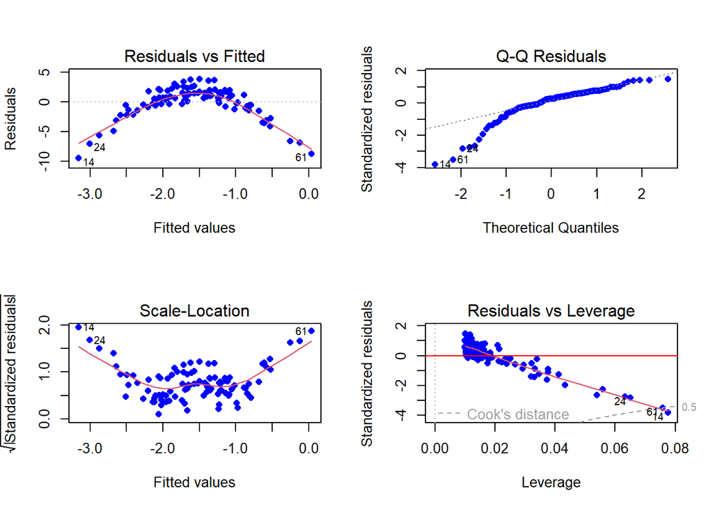

  ```r
  # part c
  set.seed(1)
  x = rnorm(100)
  error = rnorm(100,0,1)
  y = x - 2 * x^2 + error
  data = data.frame(x,y)

  # part d
  lm_model <- lm(y ~ x)
  par(mfrow = c(2, 2))  # Set up a 2x2 grid of plots
  plot(lm_model, pch = 16, col = "blue")  # Residuals vs Fitted plot
  abline(h = 0, col = "red")  # Add a horizontal line at y = 0
  ```

  ```r
  # part e
  set.seed(1)
  MSE_M1 = MSE_M2 = MSE_M3 = MSE_M4 = rep(0, 100)
  for(i in 1:100){
    test = data[i,]
    train = data[-i,]

    M1 = lm(y~x, data = train)
    M2 = lm(y~poly(x,2), data = train)
    M3 = lm(y~poly(x,3), data = train)
    M4 = lm(y~poly(x,4), data = train)

    M1_y = predict(M1, newdata = test)
    M2_y = predict(M2, newdata = test)
    M3_y = predict(M3, newdata = test)
    M4_y = predict(M4, newdata = test)

    MSE_M1[i] = (test$y - M1_y)^2
    MSE_M2[i] = (test$y - M2_y)^2
    MSE_M3[i] = (test$y - M3_y)^2
    MSE_M4[i] = (test$y - M4_y)^2
  }

  mean(MSE_M1)
  ```

  ```
  ## [1] 7.288162
  ```

  ```r
  mean(MSE_M2)
  ```

  ```
  ## [1] 0.9374236
  ```

  ```r
  mean(MSE_M3)
  ```

  ```
  ## [1] 0.9566218
  ```

  ```r
  mean(MSE_M4)
  ```

  ```
  ## [1] 0.9539049
  ```

### Bootstraping

- HW7 Problem 3

  ```r
  library(ISLR2)
  n=dim(Boston)[1]
  # estimate for the population mean of medv
  muhat = mean(Boston$medv)

  # estimate of the standard error of ˆµ using an analytical formula
  sd(Boston$medv)/sqrt(n) # interpret as the amount of variability around our estimate for mu
  ```

  ```
  ## [1] 0.4088611
  ```

  ```r
  #  estimate the standard error ˆµ using the bootstrap
  # How does this compare to your answer from (b)?
  B = 2000
  muhat_boot = rep(0,2000)
  for(b in 1:B){
    index = sample(1:n,n,replace=TRUE)
    bootstrap = Boston[index,]
    muhat_boot[b] = mean(bootstrap$medv)
  }
  sqrt(sum((muhat_boot-mean(muhat_boot))^2)/(B-1))
  ```

  ```
  ## [1] 0.4026346
  ```

  ```r
  # Using bootstrap, provide a 95% confidence interval for the mean of medv
  # Compare it to results using analytical formulas.
  umed_star = mean(Boston$medv, na.rm=TRUE)
  se_umed_star = sqrt(sum((muhat_boot-mean(muhat_boot))^2)/(B-1))
  B = 500
  m = 100
  Fstar = rep(0,B)
  umed_m = rep(0,m)
  for(b in 1:B){
    index = sample(1:n,n,replace=TRUE)
    bootsample=Boston[index,]
    mean = mean(bootsample$medv)
    for(i in 1:m){
      index2 = sample(index,n,replace=TRUE)
      bootsample2 = Boston[index2,]
      umed_m[i] = mean(bootsample2$medv)
    }
    se_umed = sqrt(sum((umed_m-mean(umed_m))^2)/(m-1))
    Fstar[b] = (mean - umed_star)/se_umed
  }
  quantile(Fstar,c(0.025,0.975))
  ```

  ```
  ##      2.5%     97.5%
  ## -2.222941  2.064865
  ```

  ```r
  umed_star + quantile(Fstar,0.025)*se_umed_star
  ```

  ```
  ##     2.5%
  ## 21.63777
  ```

  ```r
  umed_star + quantile(Fstar,0.975)*se_umed_star
  ```

  ```
  ##    97.5%
  ## 23.36419
  ```

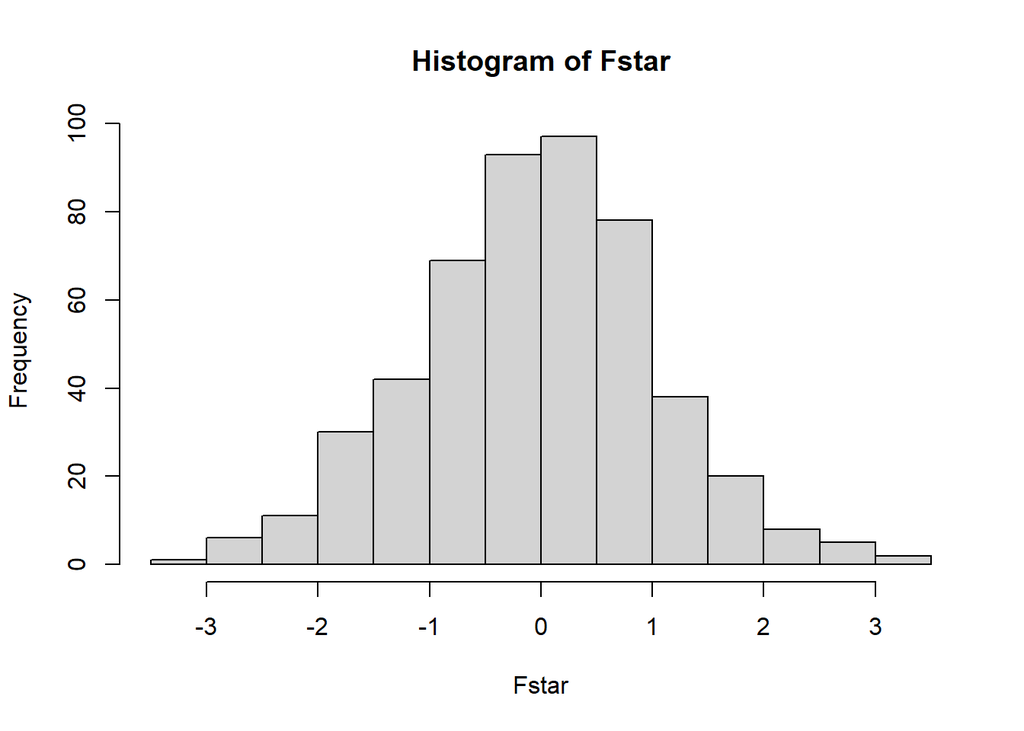

  ```r
  hist(Fstar)
  ```

  ```r
  t.test(Boston$medv)
  ```

  ```
  ##
  ##  One Sample t-test
  ##
  ## data:  Boston$medv
  ## t = 55.111, df = 505, p-value < 2.2e-16
  ## alternative hypothesis: true mean is not equal to 0
  ## 95 percent confidence interval:
  ##  21.72953 23.33608
  ## sample estimates:
  ## mean of x
  ##  22.53281
  ```

  ```r
  # provide an estimate ˆµmed for the median value of medv
  muhat_med = median(Boston$medv)
  muhat_med
  ```

  ```
  ## [1] 21.2
  ```

  ```r
  # estimate the standard error of ˆµmed.
  # Since there is no simple formula for computing standard error of the median, use bootstrap
  B = 2000
  muhat_med_boot = rep(0,2000)
  for(b in 1:B){
    index = sample(1:n,n,replace=TRUE)
    bootstrap = Boston[index,]
    muhat_med_boot[b] = median(bootstrap$medv)
  }
  sqrt(sum((muhat_med_boot-mean(muhat_med_boot))^2)/(B-1))
  ```

  ```
  ## [1] 0.3715007
  ```

  ```r
  # provide an estimate ˆµ0.1, the 10th percentile of medv
  quantile(Boston$medv,0.1)
  ```

  ```
  ##   10%
  ## 12.75
  ```

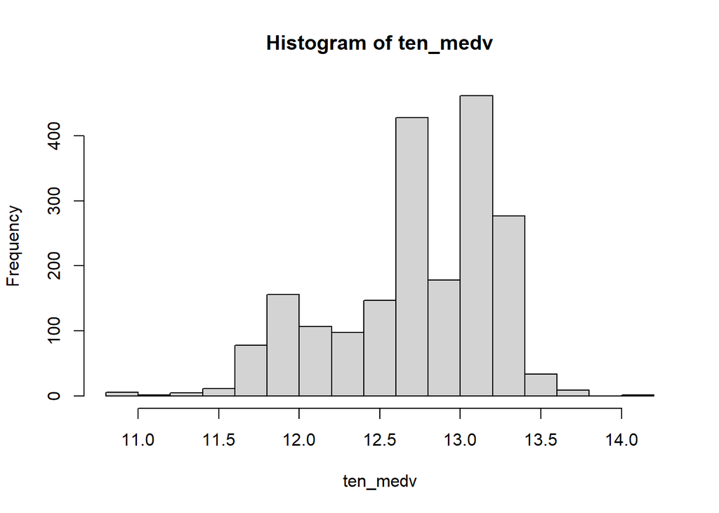

  ```r
  # Use bootstrap to estimate the standard error of ˆµ0.1
  B = 2000
  ten_medv = rep(0,2000)
  for(b in 1:B){
    index = sample(1:n,n,replace=TRUE)
    bootstrap = Boston[index,]
    ten_medv[b] = quantile(bootstrap$medv,0.1)
  }
  hist(ten_medv)
  ```

  ```r
  sqrt(sum((ten_medv-mean(ten_medv))^2)/(B-1))
  ```

  ```
  ## [1] 0.4973712
  ```

- HW7 Problem 4
  1. What is the probability that the first bootstrap observation is the jth observation from the original sample?
     - 1/n. Each observation has an equal chance of being selected
  2. What is the probability that the first bootstrap observation is not the jth observation from the original sample?
     - 1 - 1/n . The probability it will appear is 1/n so 1-1/n is just the complement
  3. What is the probability that the jth observation from the original sample is not in the bootstrap sample?
     - $(1-1/n)^n$
  4. When n = 5, what is the probability that the jth observation is in the bootstrap sample?
     - $1-(1-(1/5))^5 = 0.67232$
  5. When n = 100, what is the probability that the jth observation is in the bootstrap sample?
     - $1-(1-(1/100))^100 = 0.633967$
  6. Create a plot (in R) that displays, for each integer value of n from 1 to 100,000, the probability that the jth observation is in the bootstrap sample
     - plot starts to converge
  7. What is the probability that the jth observation is in a bootstrap sample of size n = 100? Suppose j = 5. Repeatedly create bootstrap samples, and each time we record whether or not the fifth observation is contained in the bootstrap sample.

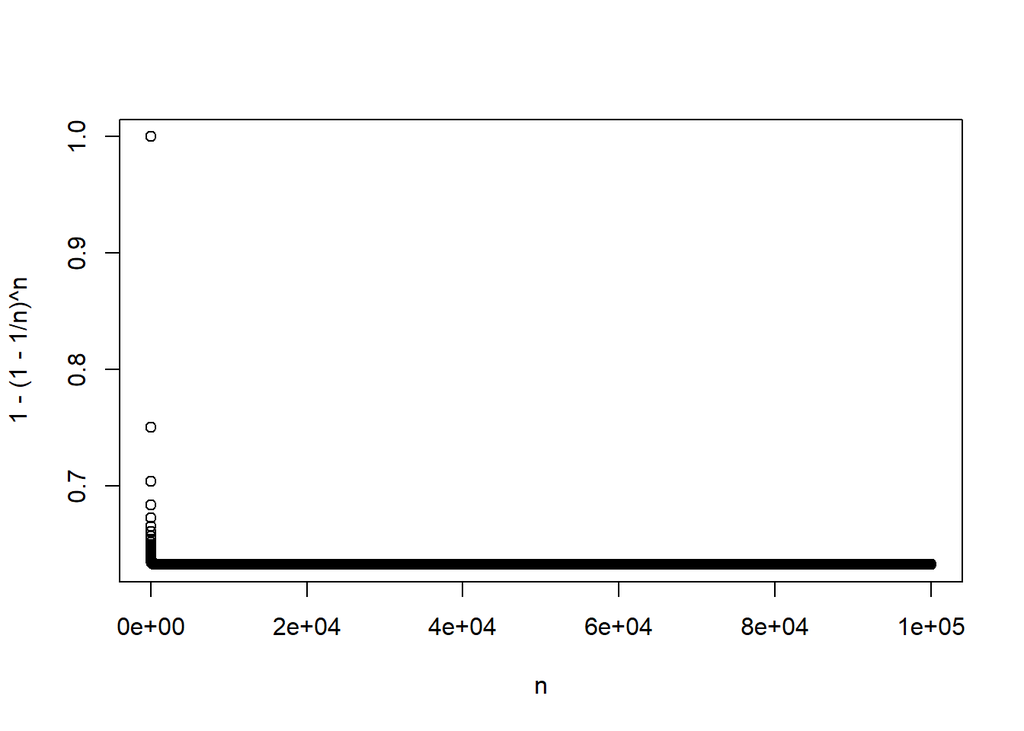

  ```r
  # part g
  n = 1:100000
  plot(n, 1 - (1 - 1/n)^n)
  ```

  ```r
  # part h
  results <- rep(NA, 10000)
  for(i in 1:10000){
    results[i] <- sum(sample(1:100, rep=TRUE) == 5) > 0
  }
  mean(results)
  ```

  ```
  ## [1] 0.6241
  ```

- Midterm 2 Question 2: Part 2, Part 3
  2. Bootstrap the standard error of $\hat{P}(Y=1 | age=50)$
  3. Bootstrap a 95% confidence interval for P(Y=1|age=50). Suppose that the standard error of $\hat{P}(Y=1 | age=50)$ from the original heart dataset is 0.026

  ```r
  heart = read.table('https://hastie.su.domains/ElemStatLearn/datasets/SAheart.data', sep=",",head=T,row.names=1)

  ######### Part 1 ###########
  glm.fit = glm(chd ~ age, data=heart, family="binomial")
  # Create a data frame with age=50
  x = data.frame(age=50)
  predicted_probability = predict(glm.fit, newdata=x, type='response')
  predicted_probability
  ```

  ```
  ##         1
  ## 0.4215756
  ```

  ```r
  ######### Part 2 ###########
  B = 2000
  n = dim(heart)[1]
  beta_0 = rep(0,2000)
  for(b in 1:B){
    index = sample(1:n,n,replace=TRUE)
    bootsample = heart[index,]
    glm.fit = glm(chd ~ age, data=bootsample, family="binomial")
    x = data.frame(age=50)
    beta_0[b] = predict(glm.fit, newdata=x, type='response')
  }
  sqrt(sum((beta_0-mean(beta_0))^2)/(B-1))
  ```

  ```
  ## [1] 0.02685973
  ```

  ```r
  prob + quantile(Fstar,0.025)*original_se
  ```

  ```
  ##         1
  ## 0.3703344
  ```

  ```r
  prob + quantile(Fstar,0.975)*original_se
  ```

  ```
  ##         1
  ## 0.4658726
  ```

### Purpose of bootstrapping

- Resampling technique used in statistics to estimate the sampling distribution of a statistic by resampling with replacement from the observed ata. The primary purpose of boostrapping is to assess the variablity of a sample statistic and to provide confidence intervals for the parameter estimates.

### Strengths and limitations

- Bootstrap
  - Strengths
    - doesn’t rely on specific assumptions about the underlying distribution of the data. This makes it more robust and applicable to a wide range of scenarios
    - can be applied to various statistical measures and be useful when dealing with complex or unknown distributions
  - Limitations
    - results of bootstrapping heavily depend on the quality and representativeness of the original sample. if the original sample is baised or unrepresentative, bootstrapping may not provide accurate estimates
    - involves resampling from the dataset multiple times, and can be computationally intensive, especially for large datasets
    - can be sensitive to outliers and the resampling process may generate biased estimates in the presence of extreme values
- Cross Validation
  - model evaluation technique to assess how well a predictive model generalizes to an independent dataset. Helps in estimating the performance of a model and detecting issues like overfitting
  - Strengths
    - provides more accurate estimate of a model’s performance by using multiple train-test splits, helping to reduce overfitting
    - in situations with limited data, cross validation allows for efficient use of available samples by using them for both training and testing
  - Limitations
    - can be computationally expensive, especially for large datasets

## 7. Regularization: Ridge and Lasso

### Motivation for shrinkage methods

- lies in addressing the issue of overfitting in predictive models. Overfitting occurs when a model fits the training data too closely, capturing noise and making it perform poorly on new, unseen data. Shrinkage methods add a penalty term to the model’s cost function, discouraging the model from assigning excessively large weights to predictors

### Setup the models. Etimate parameters in regularized models (mathematically and conceptually)

- Ridge Regression
  - find $\hat{\beta}^R$ that minimizes:  
    $\hat{\beta}^R = min_\beta (\sum_{i=1}^n (y_i - (\beta_0 + \beta_1X_1 + ... + \beta_pX_p))^2 + \lambda \sum_{j=1}^p \beta j^2), \lambda>0$
- Lasso
  - $\hat{\beta}^{lasso} = min_\beta (\sum_{i=1}^n (y_i - (\beta_0 + \beta_1X_1 + ... + \beta_pX_p))^2 + \lambda \sum_{j=1}^p |\beta j|)$

### When the methods break down

- Ridge Regression may not perform well when the majority of predictors are irrelevant
- Lasso may not perform well when there is high multicollinearity among predictors

### When the methods do well

- Ridge Regression
  - useful in improving prediction accuracy
  - will always result in a full model with all p predictors
  - use if you believe all predictors are somewhat important
  - can handle multicollinearity
  - inference can be done relatively straightforward
  - HW6 Problem 3
    1. Split the data set into a training and a test set. Please set.seed(12) so that we can all have the same results
    2. Fit a ridge regression model (using all predictors) on the training set. The function glmnet, by default, internally scales the predictor variables so that they will have standard deviation
1. Explain why this scaling is necessary when implementing regularized models. (c) Find an optimal λ for the ridge regression model on the training set by using 5-fold crossvalidation (d) What is the value of the l2 norm of the estimated regression coefficients (excluding the intercept) associated with the optimal λ for ridge regression? You can evaluate this from the training set. (e) Using that optimal λ, evaluate your trained ridge regression model on the test set. Report the test MSE obtained. (f) Find an optimal λ for the lasso regression model on the training set by using 5-fold crossvalidation. Report the optimal λ here. (g) What is the value of the l1 norm of the estimated regression coefficients (excluding the intercept) associated with the optimal λ for lasso regression? You can evaluate this from the training set. (h) Using that optimal λ, evaluate your trained lasso regression model on the test set. Report the test MSE obtained (i) How accurately can we predict the number of college applications received? Is there much difference among the test errors resulting from these two approaches?

   ```r
   library(ISLR)
   library(glmnet)
   data(College)

   # part a
   n=dim(College)[1]
   set.seed(12)
   train_index = sample(1:n,n/2,replace=F)
   train_college = College[train_index,]
   test_college = College[-train_index,]

   # part b
   train_x = model.matrix(Apps~.,data=train_college)[,-1]
   train_y = train_college$Apps
   grid = 10^seq(10,-2,length=100)
   ridge.train=glmnet(train_x, train_y, alpha=0, lambda=grid)

   # part c
   set.seed(12)
   cv.out = cv.glmnet(train_x, train_y, alpha=0, lambda=grid, nfolds=5)
   bestlambda = cv.out$lambda.min
   bestlambda
   ```

   ```
   ## [1] 0.01
   ```

   ```r
   final = glmnet(train_x,train_y,alpha=0, nfolds=5, lambda=bestlambda)
   coef(final)
   ```

   ```
   ## 18 x 1 sparse Matrix of class "dgCMatrix"
   ##                        s0
   ## (Intercept) -342.89659816
   ## PrivateYes  -532.68915005
   ## Accept         1.39925483
   ## Enroll        -0.50932183
   ## Top10perc     44.58741665
   ## Top25perc    -11.93637109
   ## F.Undergrad    0.09141534
   ## P.Undergrad    0.01490101
   ## Outstate      -0.05685207
   ## Room.Board     0.14430662
   ## Books          0.03317910
   ## Personal      -0.01087533
   ## PhD           -7.33438068
   ## Terminal      -5.22342208
   ## S.F.Ratio      6.67578034
   ## perc.alumni   -5.93259051
   ## Expend         0.08811610
   ## Grad.Rate      8.10005854
   ```

   ```r
   # part d
   coefficients_final = coef(final)[-1]

   # Calculate the L2 norm of the coefficients
   l2_norm = sqrt(sum(coefficients_final^2))
   print(l2_norm)
   ```

   ```
   ## [1] 534.899
   ```

   ```r
   # part e
   test_x = model.matrix(Apps~., data=test_college)[,-1]
   test_y = test_college$Apps
   ridge.pred = predict(final, s = bestlambda, newx = test_x)
   test_mse = mean((ridge.pred - test_y)^2)
   test_mse
   ```

   ```
   ## [1] 1418693
   ```

   ```r
   # part f
   set.seed(12)
   lasso.train = glmnet(train_x,train_y, alpha=1, lambda = grid)
   cv.out.lasso = cv.glmnet(train_x,train_y, alpha=1, nfolds=5, lambda = grid)
   bestlambda2 = cv.out.lasso$lambda.min
   bestlambda2
   ```

   ```
   ## [1] 0.01
   ```

   ```r
   final.lasso = glmnet(train_x,train_y,alpha=1,lambda=bestlambda2)
   coef(final.lasso)
   ```

   ```
   ## 18 x 1 sparse Matrix of class "dgCMatrix"
   ##                        s0
   ## (Intercept) -342.95062958
   ## PrivateYes  -532.68932056
   ## Accept         1.39922161
   ## Enroll        -0.50893549
   ## Top10perc     44.58307015
   ## Top25perc    -11.93269785
   ## F.Undergrad    0.09135636
   ## P.Undergrad    0.01490151
   ## Outstate      -0.05684174
   ## Room.Board     0.14429724
   ## Books          0.03311004
   ## Personal      -0.01084896
   ## PhD           -7.33354357
   ## Terminal      -5.22274921
   ## S.F.Ratio      6.67101786
   ## perc.alumni   -5.93275052
   ## Expend         0.08810875
   ## Grad.Rate      8.09880555
   ```

   ```r
   # part g
   coefficients_final_lasso = coef(final.lasso)[-1]

   # Calculate the L1 norm of the coefficients
   l1_norm = sum(abs(coefficients_final_lasso))
   print(l1_norm)
   ```

   ```
   ## [1] 624.8116
   ```

   ```r
   # part h
   lasso.pred = predict(lasso.train, s=bestlambda2, newx=test_x)
   mean((lasso.pred-test_y)^2)
   ```

   ```
   ## [1] 1417067
   ```

- Lasso
  - regularizes and performs model selection
  - generally works well when only a subset of predictors are actually important
  - inference not as straightforward to carry out
  - HW7 Problem 2
    1. data cleaning
    2. Fit a ridge regression model. Replicate the example we had in class to obtain the the optimal λ that minimizes the 10-fold CV. Present a plot of the cross-validation error as a function of λ. Report that value here and call it λ ridge min
    3. Naturally, if we had taken a different training/test set or a different set of folds to carry out cross-validation, our optimal λ and therefore test error would change. An alternative is to select λ using the one-standard error rule. The idea is, instead of picking the λ that produces the smallest CV error, we pick the model whose CV error is within one standard error of the lowest point on the curve you produced in part (b). The intention is to produce a more parimonious model. The glmnet function does all of this hard work for you and we can extract the λ based on this rule using the following code: cv.out$lambda.1se (assuming your cv.glmnet object is named cv.out). Report your that λ here and call it λ ridge 1se
    4. Fit a lasso regression model. Replicate the example we had in class to obtain the the optimal λ that minimizes the 10-fold CV. Present a plot of the cross-validation error as a function of λ. Report that value here and call it λ lasso min
    5. For lasso, report the optimal λ using the smallest standard error rule and called it λ lasso 1se
    6. Evaluate the ridge regression models on your test set using λ = λ ridge min and λ = λ ridge 1se . Evaluate the lasso models on your test set using λ lasso min and λ lasso 1se . Report the test MSEs from these 4 models.
    7. Report the coefficient estimates from ridge using λ ridge min and λ ridge 1se and likewise for the lasso models. How do the ridge regression estimates compare to those from the lasso? How do the coefficient estimates from using λmin compare to those from the one-standard error rule?
    8. Train and implement elastic net. Report the optimal values for α and λ that produce the smallest 10-fold cross-validation error. Call these values α enet and λ enet
    9. Evaluate the elastic net on your test set using the optimal values for α enet and λ enet
    10. Which model performs the best in terms of prediction? Explain any intuition as to why
    11. what handful of features would you tell this player to focus on?

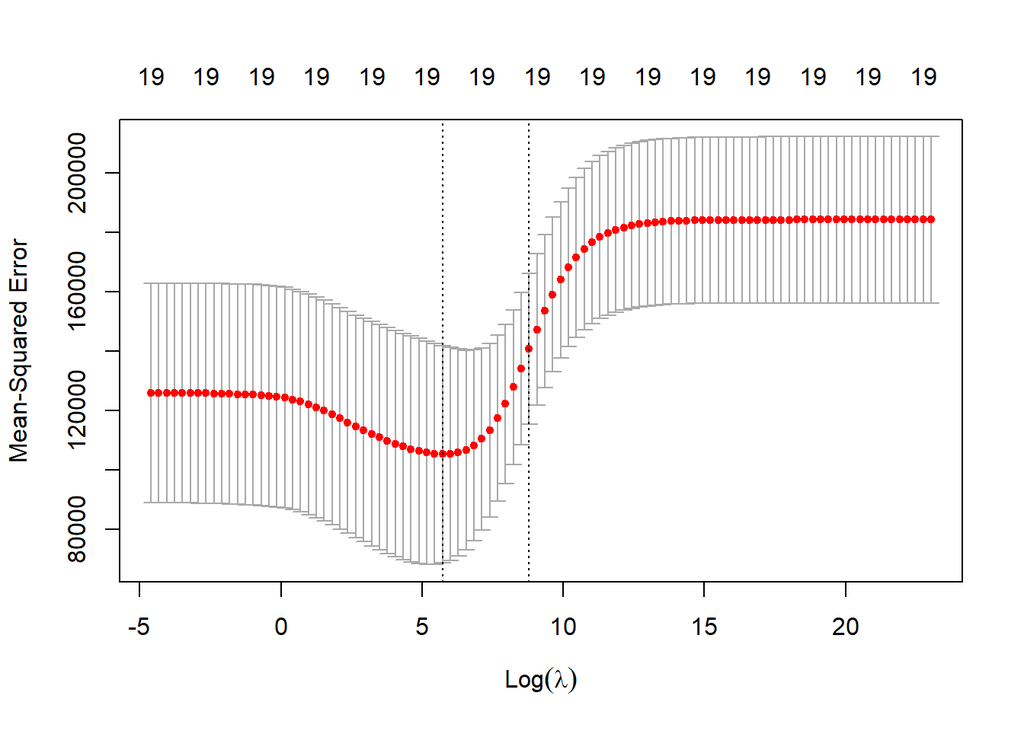

  ```r
  # part a
  library(ISLR2)
  library(glmnet)
  Hitters = na.omit(Hitters)
  n = nrow(Hitters) #there are 263 observations
  x = model.matrix(Salary ~.,data=Hitters)[,-1] #19 predictors
  Y = Hitters$Salary
  set.seed(1)
  train = sample(1:nrow(x), nrow(x)/2)
  test=(-train)
  Y.test = Y[test]

  # part b
  grid = 10^seq(10, -2, length=100)
  ridge.train = glmnet(x[train,], Y[train], alpha=0, lambda=grid)
  set.seed(1)
  cv.out = cv.glmnet(x[train,], Y[train], alpha=0, lambda=grid)
  plot(cv.out)
  ```

  ```r
  ridgeMin = cv.out$lambda.min
  ridgeMin
  ```

  ```
  ## [1] 305.3856
  ```

  ```r
  # part c
  ridgelse = cv.out$lambda.1se
  ridgelse
  ```

  ```
  ## [1] 6579.332
  ```

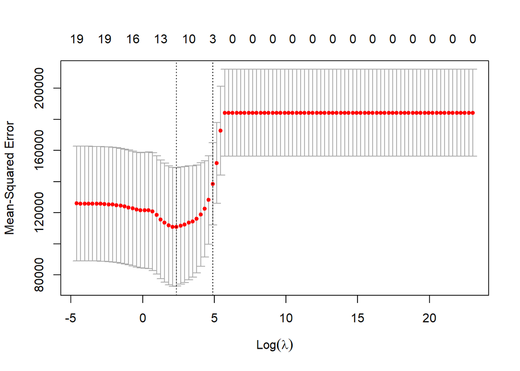

  ```r
  # part d
  lasso.train = glmnet(x[train,],Y[train],alpha=1, lambda = grid)
  set.seed(1)
  cv.out.lasso = cv.glmnet(x[train,],Y[train],alpha = 1, lambda = grid)
  plot(cv.out.lasso)
  ```

  ```r
  lassoMin = cv.out.lasso$lambda.min
  lassoMin
  ```

  ```
  ## [1] 10.72267
  ```

  ```r
  # part e
  lassolse = cv.out.lasso$lambda.1se
  lassolse
  ```

  ```
  ## [1] 132.1941
  ```

  ```r
  # part f
  ridge.min = predict(ridge.train, s=ridgeMin, newx = x[test,])
  mean((ridge.min-Y.test)^2)
  ```

  ```
  ## [1] 140081.9
  ```

  ```r
  ridge.lse = predict(ridge.train, s=ridgelse, newx=x[test,])
  mean((ridge.lse-Y.test)^2)
  ```

  ```
  ## [1] 165523.3
  ```

  ```r
  lasso.min = predict(lasso.train, s=lassoMin, newx = x[test,])
  mean((lasso.min-Y.test)^2)
  ```

  ```
  ## [1] 143527.7
  ```

  ```r
  lasso.lse = predict(lasso.train, s=lassolse, newx = x[test,])
  mean((lasso.lse-Y.test)^2)
  ```

  ```
  ## [1] 157773.7
  ```

  ```r
  # part g
  coef(glmnet(x,Y,alpha=0, lambda = ridgeMin))
  ```

  ```
  ## 20 x 1 sparse Matrix of class "dgCMatrix"
  ##                       s0
  ## (Intercept)  13.82836042
  ## AtBat         0.07185690
  ## Hits          0.87923686
  ## HmRun         0.53787861
  ## Runs          1.07209934
  ## RBI           0.87940924
  ## Walks         1.65046005
  ## Years         1.20215837
  ## CAtBat        0.01135929
  ## CHits         0.05850049
  ## CHmRun        0.41307137
  ## CRuns         0.11642426
  ## CRBI          0.12329787
  ## CWalks        0.05014536
  ## LeagueN      22.83614180
  ## DivisionW   -81.02283953
  ## PutOuts       0.17012394
  ## Assists       0.03105466
  ## Errors       -1.42556422
  ## NewLeagueN    8.95856315
  ```

  ```r
  coef(glmnet(x,Y, alpha=0, lambda = ridgelse))
  ```

  ```
  ## 20 x 1 sparse Matrix of class "dgCMatrix"
  ##                        s0
  ## (Intercept) 342.454584686
  ## AtBat         0.055333136
  ## Hits          0.211556250
  ## HmRun         0.769972808
  ## Runs          0.349986914
  ## RBI           0.359997480
  ## Walks         0.442625783
  ## Years         1.618528505
  ## CAtBat        0.004665257
  ## CHits         0.017500453
  ## CHmRun        0.131097056
  ## CRuns         0.035107946
  ## CRBI          0.036259312
  ## CWalks        0.036996438
  ## LeagueN       0.609025156
  ## DivisionW   -10.288271440
  ## PutOuts       0.026487928
  ## Assists       0.004086746
  ## Errors       -0.042674529
  ## NewLeagueN    0.820596873
  ```

  ```r
  coef(glmnet(x,Y,alpha=1,lambda=lassoMin))
  ```

  ```
  ## 20 x 1 sparse Matrix of class "dgCMatrix"
  ##                        s0
  ## (Intercept)    0.51575459
  ## AtBat          .
  ## Hits           1.99112415
  ## HmRun          .
  ## Runs           .
  ## RBI            .
  ## Walks          2.24863573
  ## Years          .
  ## CAtBat         .
  ## CHits          .
  ## CHmRun         0.03475938
  ## CRuns          0.21861371
  ## CRBI           0.40630057
  ## CWalks         .
  ## LeagueN       16.88981996
  ## DivisionW   -113.97530666
  ## PutOuts        0.23441763
  ## Assists        .
  ## Errors        -0.62895975
  ## NewLeagueN     .
  ```

  ```r
  coef(glmnet(x,Y,alpha=1, lambda=lassolse))
  ```

  ```
  ## 20 x 1 sparse Matrix of class "dgCMatrix"
  ##                       s0
  ## (Intercept) 316.02183375
  ## AtBat         .
  ## Hits          0.72112214
  ## HmRun         .
  ## Runs          .
  ## RBI           .
  ## Walks         0.56907852
  ## Years         .
  ## CAtBat        .
  ## CHits         .
  ## CHmRun        .
  ## CRuns         0.09666601
  ## CRBI          0.25371287
  ## CWalks        .
  ## LeagueN       .
  ## DivisionW     .
  ## PutOuts       .
  ## Assists       .
  ## Errors        .
  ## NewLeagueN    .
  ```

  ```r
  # part h
  alpha = seq(0.01, 0.99, by=0.01)
  cv_error = rep(NA,length(alpha))

  for (i in 1:length(alpha)){
    set.seed(1)
    cv_elastic = cv.glmnet(x[train,], Y[train], alpha = alpha[i], lambda=grid)
    cv_error[i] = min(cv_elastic$cvm)
  }

  best_alpha = alpha[which.min(cv_error)]
  best_alpha
  ```

  ```
  ## [1] 0.01
  ```

  ```r
  ## find the optimal lambda with best_alpha
  set.seed(1)
  elastic_cv = cv.glmnet(x[train,], Y[train], alpha = best_alpha,lambda=grid)
  elastic_cv$lambda.min
  ```

  ```
  ## [1] 305.3856
  ```

  ```r
  # part i
  enet.train = glmnet(x[train,],Y[train],alpha=best_alpha,lambda=grid)
  enet.pred = predict(enet.train,s=elastic_cv$lambda.min,newx=x[test,])
  mean((enet.pred-Y.test)^2)
  ```

  ```
  ## [1] 140023.6
  ```

  ```r
  coef(glmnet(x,Y,alpha=best_alpha, lambda = elastic_cv$lambda.min))
  ```

  ```
  ## 20 x 1 sparse Matrix of class "dgCMatrix"
  ##                        s0
  ## (Intercept)  22.743597459
  ## AtBat         0.067868722
  ## Hits          0.874133013
  ## HmRun         0.391691609
  ## Runs          1.052405668
  ## RBI           0.872211145
  ## Walks         1.641289904
  ## Years         1.011724611
  ## CAtBat        0.011372062
  ## CHits         0.058405408
  ## CHmRun        0.406642158
  ## CRuns         0.115778670
  ## CRBI          0.123115233
  ## CWalks        0.048796707
  ## LeagueN      19.721204285
  ## DivisionW   -78.100727965
  ## PutOuts       0.165718626
  ## Assists       0.009139904
  ## Errors       -0.915568522
  ## NewLeagueN    6.300067551
  ```

### Distinction between ridge and lasso - why can lasso set regression coefficients to 0?

- Ridge Regression
  - the regularization term is proportional to the sum of squared coefficients. the regularization term penalizes the sum of the squared values of the coefficients.
  - the penalty term shrinks the coefficients towards zero, but rarely sets any of them exactly to zero
- Lasso
  - the regularization term is proportional to the sum of absolute values of the coefficients. the regularization term penalizes the absolute values of the coefficients
  - the penalty can force some coefficients to exactly zero
  - the lasso penalty has a sparsity-inducing property. as the strength of $\lambda$ increases, certain coefficients become increasingly penalized and driven to zero (feature selection)
    - bias increases as $\lambda$ increases
    - variance decreases as $\lambda$ decreases

### Elastic net: strengths and weaknesses

- addresses some shortcomings of lasso
  - doesn’t do well in presence of multicollinearity
  - doesn’t work well when $p \geq n$ (high dimensionality)

## 8. Classification

### Models available to use to carry out classification

- Logistic Regression
  - model the probability that Y belongs to a category
  - what threshold will give smallest overall misclassification rate?
    - Threshold of 0.5. This mimics Bayes Classifier, which is the gold standard
- Linear Discriminant Analysis
  - generative model that finds the linear combination of features that best separates two or more classes.
  - The parameters in LDA are estimated using the mean and covariance matrix of the features for each class.
- Quadratic Discriminant Analysis
  - Similar to LDA, but QDA allows for different covariance matrices for each class.
  - The parameters are estimated using the mean and covariance matrix of the features for each class.
- Naive Bayes
  - Naive Bayes is a probabilistic model based on Bayes’ theorem with the “naive” assumption of independence among features.
  - Parameters are estimated based on the likelihood of each feature given the class and the prior probabilities of the classes.
- K-nearest neighbor
  - KNN classifies an observation by a majority vote of its k-nearest neighbors.
  - non-parametric. It makes no underlying assumption about the data or the shape of the decision boundary